# STAT 545 hw-01 (gapminder)

September 11, 2019

## Homework 1, Exercise 3

This is the third exercise in assignment one for STAT 545. The goal of this exercise is to create slides using R Markdown.

## 'gapminder' dataset

This exercise uses the same analysis of the 'gapminder' dataset as in hw01 Exercise 2.

```r
# load the packages required for this analysis
library(gapminder)
```

The dataset contains information on life expectancy, GDP per capita, and population by country.

## Data structure

Explore the data structure and type by executing some simple commands.

```r
str(gapminder)  # structure
```

```
## Classes 'tbl_df', 'tbl' and 'data.frame':    1704 obs. of  6 variables:
##  $ country  : Factor w/ 142 levels "Afghanistan",..: 1 1 1 1 1 1 1 1 1 1 ...
##  $ continent: Factor w/ 5 levels "Africa","Americas",..: 3 3 3 3 3 3 3 3 3 3 ...
##  $ year     : int  1952 1957 1962 1967 1972 1977 1982 1987 1992 1997 ...
##  $ lifeExp  : num  28.8 30.3 32 34 36.1 ...
##  $ pop      : int  8425333 9240934 10267083 11537966 13079460 14880372 12881816 13867957 16317921 22227415 ...
##  $ gdpPercap: num  779 821 853 836 740 ...
```

Calling 'str()' yields lots of information about this dataset (length, data structure and type).

## Dataset Exploration

### Countries

Identify how many countries are included in the gapminder dataset (*Note:* calling 'str()' showed this number as levels in the Factor 'country')

```r
# see if Canada is a country in the dataset
any(gapminder$country == "Canada")
```

```
## [1] TRUE
```

```r
#  how many countries are included?
length(unique(gapminder$country))
```

```
## [1] 142
```

## Dataset Exploration

### Span of Dataset (Years)

This dataset includes life expectancy ("lifeExp") in each country. What is the range of this data and how does it vary? Using the 'range()' function yields the lowest and highest end members in the data (min & max).

```r
# what is the range of years included?
range(gapminder$year)
```

```
## [1] 1952 2007
```

```r
# what is the range of life expectancies across the world?
range(gapminder$lifeExp)
```

```
## [1] 23.599 82.603
```

## Dataset Exploration

### Life Expectancy

Identify countries with the lowest and highest life expectancy, and associated information.

```r
# subset using the index command
# minimum life expectancy
gapminder[which(gapminder$lifeExp == min(gapminder$lifeExp)), ]
```

```
## # A tibble: 1 x 6
##   country continent  year lifeExp     pop gdpPercap
##   <fct>   <fct>     <int>   <dbl>   <int>     <dbl>
## 1 Rwanda  Africa     1992    23.6 7290203      737.
```

The lowest life expectancy (23.6 years) was in 1992 in Rwanda, Africa.

## Dataset Exploration

### Life Expectancy

```r
# maximum life expectancy?
gapminder[which(gapminder$lifeExp == max(gapminder$lifeExp)), ]
```

```
## # A tibble: 1 x 6
##   country continent  year lifeExp       pop gdpPercap
##   <fct>   <fct>     <int>   <dbl>     <int>     <dbl>
## 1 Japan   Asia       2007    82.6 127467972    31656.
```

The highest life expectancy (82.6 years) was in Japan, Asia in 2007.

## Dataset Exploration

### Canada, eh

When was Canadian life expectancy lowest?

```r
# subset the gapminder data for Canada
Canada_df <- gapminder[gapminder$country == "Canada", ]

# find minimum and maximum life expectancy
Canada_df[which(Canada_df$lifeExp == min(Canada_df$lifeExp)), ]
```

```
## # A tibble: 1 x 6
##   country continent  year lifeExp      pop gdpPercap
##   <fct>   <fct>     <int>   <dbl>    <int>     <dbl>
## 1 Canada  Americas   1952    68.8 14785584    11367.
```

The life expectancy in Canada was lowest in the first recorded year of this dataset (1952, 68.8 years).

## Canada, eh

When was Canadian life expectancy highest?

```r
Canada_df[which(Canada_df$lifeExp == max(Canada_df$lifeExp)), ]
```

```
## # A tibble: 1 x 6
##   country continent  year lifeExp      pop gdpPercap
##   <fct>   <fct>     <int>   <dbl>    <int>     <dbl>
## 1 Canada  Americas   2007    80.7 33390141    36319.
```

Canadian life expectancy was highest in the most recent recorded year (2007, 80.7 years).

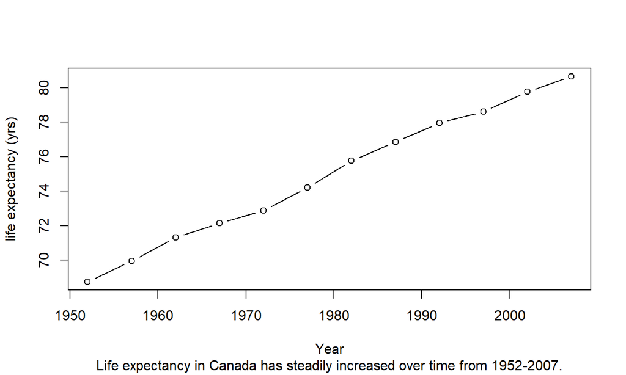

```r
# use base R to plot Canadian life expectancy over time
plot(y = Canada_df$lifeExp, x = Canada_df$year,
     ylab = "life expectancy (yrs)", xlab = "Year",
     type = "b",
     sub = "Life expectancy in Canada has steadily increased over time from 1952-2007.")
```

## Dataset Exploration

### GDP & Life Expectancy

### Is there a positive relationship between life expectancy and GDP? Is the relationship linear?

To visually explore the relationship between GDP and life expectancy, plot those data against each other.

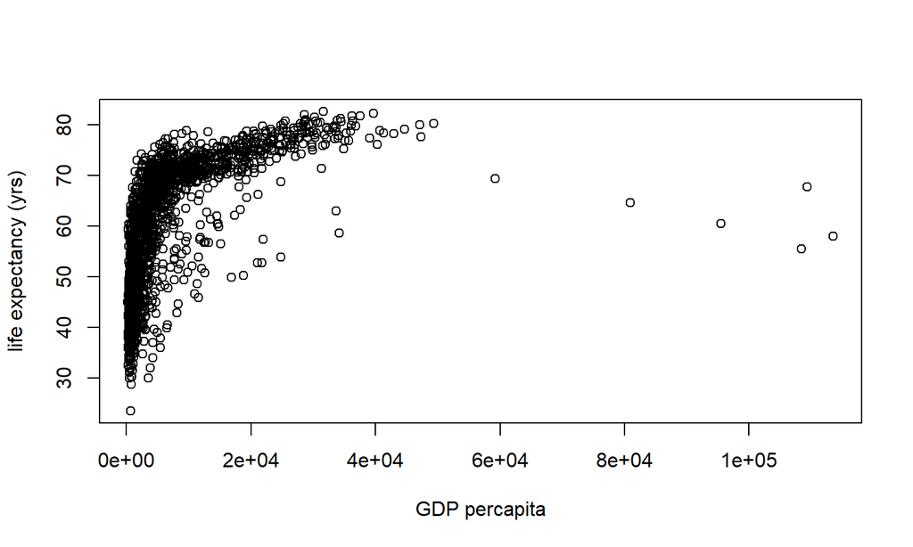

```r
# use base R to plot global life expectancy with GDP
plot(y = gapminder$lifeExp, x = gapminder$gdpPercap,
     ylab = "life expectancy (yrs)", xlab = "GDP percapita")
```